# Assignment 2 : Statistical Learning

Seungwoo,Hong 10879420 Ee June, Kim 11630566 Jin Hyun,Kim 11968850

### Objective of Analysis

The ClassifyRisk dataset which is available in the R liver package has 6 variables with 5 predictors. With this dataset this assignment, the customers would be classified as either “good risk” or “bad loss” by applying k-nearest neighbor algorithm. This is important to be illustrated because the risk classification is a one of the key factors in lots of companies.

### 1- Importing and understading the dataset (15 points)

```r
require(liver)
library( liver )
```

Now, we impcrt the *ClassifyRisk* dataset as follows:

```r
data( classifyRisk )
```

We can see the structure of the dataset by using the `str` function as follows:

```r
str( classifyRisk )
```

```
## 'data.frame':    246 obs. of  6 variables:
##  $ mortgage      : Factor w/ 2 levels "n","y": 2 1 1 2 2 1 1 1 1 1 ...
##  $ nr_loans      : int  3 2 2 2 2 2 3 2 2 2 ...
##  $ age           : int  34 37 29 33 39 28 28 25 41 26 ...
##  $ marital_status: Factor w/ 3 levels "married","other",..: 2 2 2 2 2 2 2 2 2 2 ...
##  $ income        : num  28061 28009 27615 27287 26954 ...
##  $ risk          : Factor w/ 2 levels "bad loss","good risk": 1 1 1 1 1 1 1 1 1 1 ...
```

```r
View( classifyRisk)
```

##Report a summary of the dataset by using appropriate R functions.

##What is the number of variables?

ㅁ6 variables

##Which type of variables are they?

ㅁmortgage: Categorical and binary

ㅁnr_loans: Numerical and discrete

ㅁage: Numerical and discrete

ㅁmarital_status: multinomial / Categorical and nominal

ㅁincome: Numerical and continuous

ㅁrisk: flag / Categorical and binary

##Are there any missing values?  
ㅁThere is no missing values

##What would be your strategy to deal with the missing data? ㅁWe will replace missing values with Mode or Mean

### 2- Partitioning the dataset (10 points)

Cross-validation is a type of technique to evaluate the results of a statistical analysis methods, which has a purpose of generating an independent dataset

By using Cross-Validation, we partition the *classifyRisk* dataset randomly into two groups as a train set (70%) and test set (30%). Here, we use the `partition` function from the *liver* package as follows:

```r
set.seed( 10 )

data_sets = partition( data = classifyRisk, prob = c( 0.7, 0.3 ) )

train_set = data_sets $ part1
test_set  = data_sets $ part2

train_label = train_set $ risk
test_label  = test_set $ risk
```

The `set.seed` function was used to create reproducible results.

### 3- Validate the partition (15 points)

We want to validate the partition by testing whether the proportion of the variable `risk` differs between the two data sets. We use prop-test for the difference in proportions. `

```r
table(train_label)
```

```
## train_label
##  bad loss good risk
##        93        80
```

```r
table(test_label)
```

```
## test_label
##  bad loss good risk
##        30        43
```

Check whether each proportions of goodrisk from two train set and test set is equal

```r
prop.test( x = c(80, 43), n = c( 93+ 80, 30 + 43), alternative = "two.sided"  )
```

```
##
##  2-sample test for equality of proportions with continuity correction
##
## data:  c(80, 43) out of c(93 + 80, 30 + 43)
## X-squared = 2.805, df = 1, p-value = 0.09397
## alternative hypothesis: two.sided
## 95 percent confidence interval:
##  -0.27147636  0.01824966
## sample estimates:
##    prop 1    prop 2
## 0.4624277 0.5890411
```

The p-value is 0.09397, which is larger than 0.05. So, we can not reject the null hypothesis that proportions of good risk in both sample is equal.

### 4- Appling the KNN algorithm (20 points)

Find the k-nearest neighbor predictions for the test set using k = 2 and k = 90.

Explain how you preparing the variables for the KNN algorithm. Which variables need to be normalized?

The predictors that we used in the previous question, do not have the same scale. For example, variable `income` change between 1.53012510^{4} and 7.83986210^{4}, whereas variable `mortgage` is categorical. In this case, the values of variable `income` will overwhelm the contribution of `mortgage`. To avoid this situation we use *normalization*. So, we use *min-max normalization* and transfer the predictors.

Which variables need dummy variable? Because there is only yes or no in mortgage variable, this variable needs dummy variable.

```r
knn_2  = kNN( risk ~ ., train = train_set, test = test_set, transform = "minmax" ,k = 2 )

knn_90 = kNN( risk ~ ., train = train_set, test = test_set,transform = "minmax" ,k = 90 )
```

To have an overview of the prediction result, we could use the `table` function as follows:

```r
table( knn_2 , test_label )
```

```
##            test_label
## knn_2       bad loss good risk
##   bad loss        27         8
##   good risk        3        35
```

```r
table( knn_90, test_label )
```

```
##            test_label
## knn_90      bad loss good risk
##   bad loss         6         2
##   good risk       24        41
```

### 5- Evaluate the accuracy of the predictions (10 points)

Evaluate the accuracy of the predictions using the Mean Square Error (MSE). You could use the `mse` function from the R package **liver**.

```r
MSE_2  = mse( test_label, knn_2  )
MSE_2
```

```
## [1] 0.1506849
```

```r
MSE_90 = mse( test_label, knn_90 )
MSE_90
```

```
## [1] 0.3561644
```

MSE is a common method of evaluation for accuracy of models for continuous target variables. Lower MSE means the model predicts better. When the k is increased from 2 to 90, we can that the MSE has increased. Conclusion can be that model with k= 2 is better than the one with k=90.

### 6- Optimal value of k for the kNN algorithm (15 points)

In the previous questions, to find the k-nearest neighbor for the test set, we set k = 2 and k = 90. But why 2 or 90? Find out the optimal value of `k`.

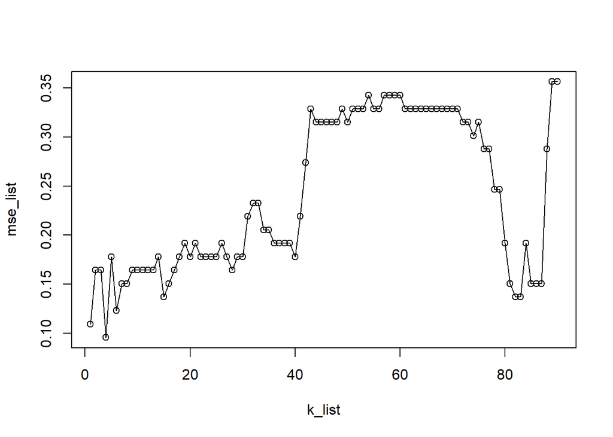

```r
k_list   = 1:90
mse_list = vector( length = length( k_list )  )

for( k in k_list ){
    knn_k = kNN( risk ~ ., train = train_set, test = test_set, transform = "minmax", k = k )
    mse_list[ k ] = mse( test_label, knn_k )
}

plot( x = k_list, y = mse_list, type = "o" )
```

From the graph above, it can be seen that the mse is the lowest when the value of k is 4. This can be verified through comparing the mse below

```r
knn_4 = kNN( risk ~ ., train = train_set, test = test_set,transform = "minmax" ,k = 4 )

MSE_2  = mse( test_label, knn_2  )
MSE_2
```

```
## [1] 0.1506849
```

```r
MSE_90 = mse( test_label, knn_90 )
MSE_90
```

```
## [1] 0.3561644
```

```r
MSE_4 = mse( test_label, knn_4 )
MSE_4
```

```
## [1] 0.1232877
```

### 7- Writing a report (15 points)

To sum up, there were several steps and codes to illustrate the result of applying the k-neaest neighbor(knn) algorithm to organize the customer. First the partitioning of the ClassifyRist dataset randomly divided the data into two groups which are train set and test set. The validation was tested by prop-test to find the proportion of variable ‘risk’ difference between the groups. In the prop-test, the null hypothesis which is “the proportion of good risk in both sample is equal” was not rejected.

Before applying the Knn algorithm some variables such as the variable income and mortgage need the normalization to avoid the inaccurate results. After coding the predictions, with ‘MSE’ the accuracy of the predictions was evaluated. This codes showed that the model with k = 2 is more accurate than the model with k =90. Finally the optimal value of the K was founded which is 4.

### 8- Bonus question (30 points)

## Applying KNN algorithm for analyizing bank dataset

### Import libraries

```r
library(liver)
library(ggplot2)
library(dplyr)
data(bank)
```

### Understanding the dataset

```r
str(bank)
```

```
## 'data.frame':    4521 obs. of  17 variables:
##  $ age      : int  30 33 35 30 59 35 36 39 41 43 ...
##  $ job      : Factor w/ 12 levels "admin.","blue-collar",..: 11 8 5 5 2 5 7 10 3 8 ...
##  $ marital  : Factor w/ 3 levels "divorced","married",..: 2 2 3 2 2 3 2 2 2 2 ...
##  $ education: Factor w/ 4 levels "primary","secondary",..: 1 2 3 3 2 3 3 2 3 1 ...
##  $ default  : Factor w/ 2 levels "no","yes": 1 1 1 1 1 1 1 1 1 1 ...
##  $ balance  : int  1787 4789 1350 1476 0 747 307 147 221 -88 ...
##  $ housing  : Factor w/ 2 levels "no","yes": 1 2 2 2 2 1 2 2 2 2 ...
##  $ loan     : Factor w/ 2 levels "no","yes": 1 2 1 2 1 1 1 1 1 2 ...
##  $ contact  : Factor w/ 3 levels "cellular","telephone",..: 1 1 1 3 3 1 1 1 3 1 ...
##  $ day      : int  19 11 16 3 5 23 14 6 14 17 ...
##  $ month    : Factor w/ 12 levels "apr","aug","dec",..: 11 9 1 7 9 4 9 9 9 1 ...
##  $ duration : int  79 220 185 199 226 141 341 151 57 313 ...
##  $ campaign : int  1 1 1 4 1 2 1 2 2 1 ...
##  $ pdays    : int  -1 339 330 -1 -1 176 330 -1 -1 147 ...
##  $ previous : int  0 4 1 0 0 3 2 0 0 2 ...
##  $ poutcome : Factor w/ 4 levels "failure","other",..: 4 1 1 4 4 1 2 4 4 1 ...
##  $ deposit  : Factor w/ 2 levels "no","yes": 1 1 1 1 1 1 1 1 1 1 ...
```

```r
summary(bank)
```

```
##       age                 job          marital         education    default
##  Min.   :19.00   management :969   divorced: 528   primary  : 678   no :4445
##  1st Qu.:33.00   blue-collar:946   married :2797   secondary:2306   yes:  76
##  Median :39.00   technician :768   single  :1196   tertiary :1350
##  Mean   :41.17   admin.     :478                   unknown  : 187
##  3rd Qu.:49.00   services   :417
##  Max.   :87.00   retired    :230
##                  (Other)    :713
##     balance      housing     loan           contact          day
##  Min.   :-3313   no :1962   no :3830   cellular :2896   Min.   : 1.00
##  1st Qu.:   69   yes:2559   yes: 691   telephone: 301   1st Qu.: 9.00
##  Median :  444                         unknown  :1324   Median :16.00
##  Mean   : 1423                                          Mean   :15.92
##  3rd Qu.: 1480                                          3rd Qu.:21.00
##  Max.   :71188                                          Max.   :31.00
##
##      month         duration       campaign          pdays
##  may    :1398   Min.   :   4   Min.   : 1.000   Min.   : -1.00
##  jul    : 706   1st Qu.: 104   1st Qu.: 1.000   1st Qu.: -1.00
##  aug    : 633   Median : 185   Median : 2.000   Median : -1.00
##  jun    : 531   Mean   : 264   Mean   : 2.794   Mean   : 39.77
##  nov    : 389   3rd Qu.: 329   3rd Qu.: 3.000   3rd Qu.: -1.00
##  apr    : 293   Max.   :3025   Max.   :50.000   Max.   :871.00
##  (Other): 571
##     previous          poutcome    deposit
##  Min.   : 0.0000   failure: 490   no :4000
##  1st Qu.: 0.0000   other  : 197   yes: 521
##  Median : 0.0000   success: 129
##  Mean   : 0.5426   unknown:3705
##  3rd Qu.: 0.0000
##  Max.   :25.0000
##
```

The summary of the dataset shows there are unknown values we need to consider: education, contact and poutcome.

### Discovering relationship between numerical variables and a target variable

#### Correlation matrix

```r
bank_numerical <- bank %>% select(age, balance, day, duration, campaign, pdays, previous, deposit)
bank_numerical$deposit <- as.integer(bank_numerical$deposit) -1

cor(bank_numerical)
```

```
##                   age      balance          day     duration     campaign
## age       1.000000000  0.083820142 -0.017852632 -0.002366889 -0.005147905
## balance   0.083820142  1.000000000 -0.008677052 -0.015949918 -0.009976166
## day      -0.017852632 -0.008677052  1.000000000 -0.024629306  0.160706069
## duration -0.002366889 -0.015949918 -0.024629306  1.000000000 -0.068382000
## campaign -0.005147905 -0.009976166  0.160706069 -0.068382000  1.000000000
## pdays    -0.008893530  0.009436676 -0.094351520  0.010380242 -0.093136818
## previous -0.003510917  0.026196357 -0.059114394  0.018080317 -0.067832630
## deposit   0.045091803  0.017905098 -0.011244208  0.401118303 -0.061147431
##                 pdays     previous     deposit
## age      -0.008893530 -0.003510917  0.04509180
## balance   0.009436676  0.026196357  0.01790510
## day      -0.094351520 -0.059114394 -0.01124421
## duration  0.010380242  0.018080317  0.40111830
## campaign -0.093136818 -0.067832630 -0.06114743
## pdays     1.000000000  0.577561827  0.10408682
## previous  0.577561827  1.000000000  0.11671444
## deposit   0.104086819  0.116714436  1.00000000
```

First to find out a relationship between numerical variables and a target variable, correlation analysis was performed. Since a target variable is coded in “yes” or “no”, we decided to recode values to integers 0 and 1. From the matrix above, only the variable duration shows a moderate to high correlation (0.4) with a target variable deposit.

#### Boxplot to compare means

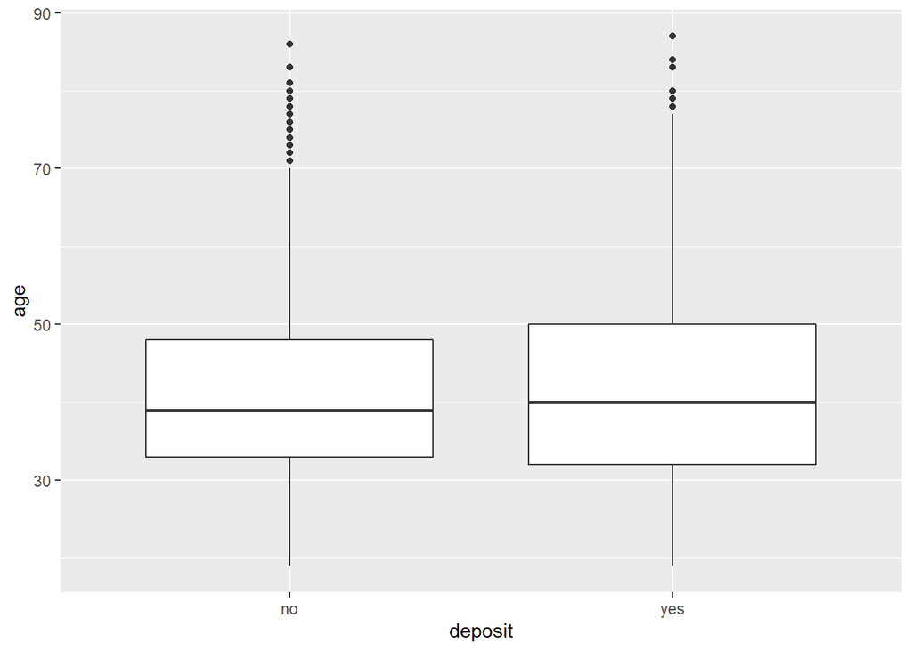

```r
ggplot(bank, aes(x = deposit, y = age)) +
  geom_boxplot()
```

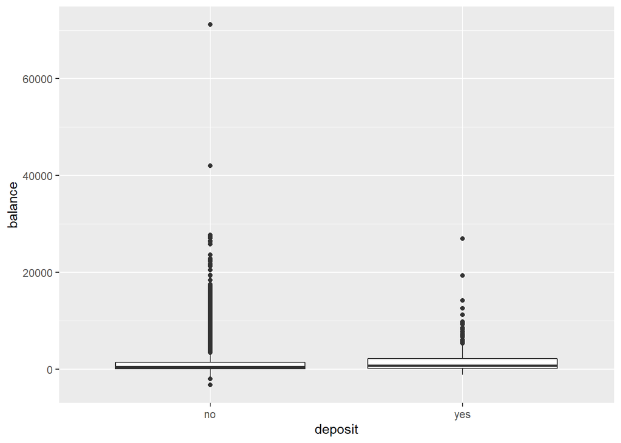

```r
ggplot(bank, aes(x = deposit, y = balance)) +
  geom_boxplot()
```

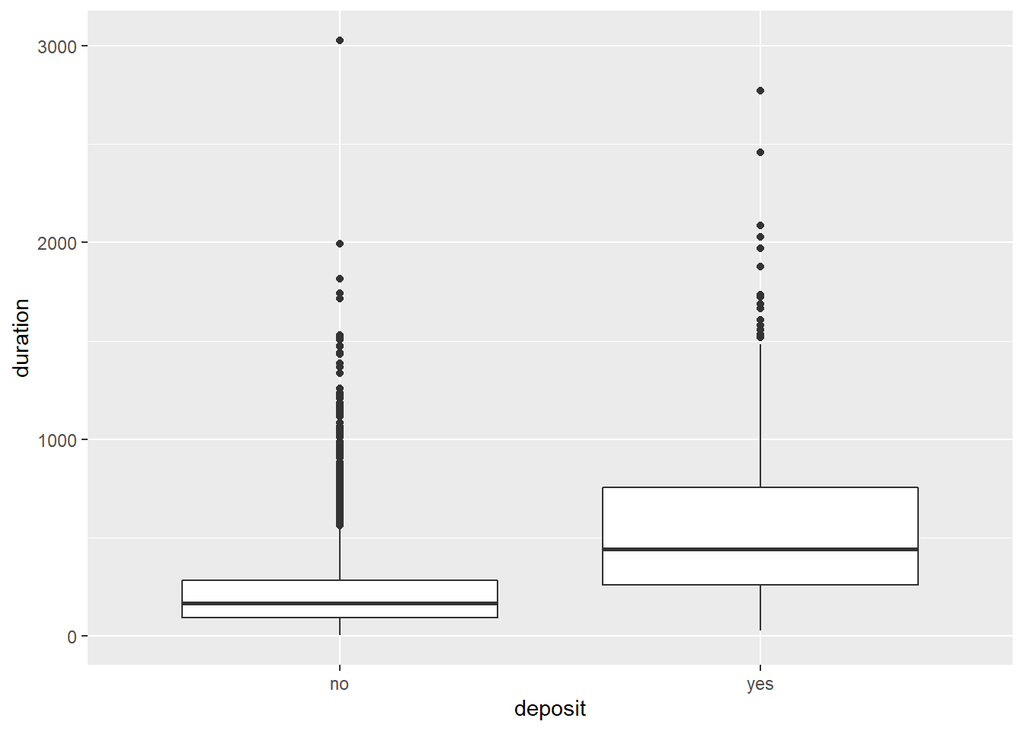

```r
ggplot(bank, aes(x = deposit, y = duration)) +
  geom_boxplot()
```

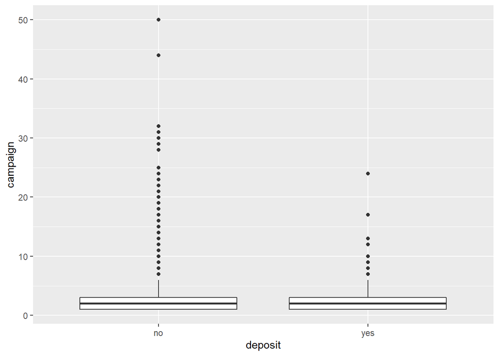

```r
ggplot(bank, aes(x = deposit, y = campaign)) +
  geom_boxplot()
```

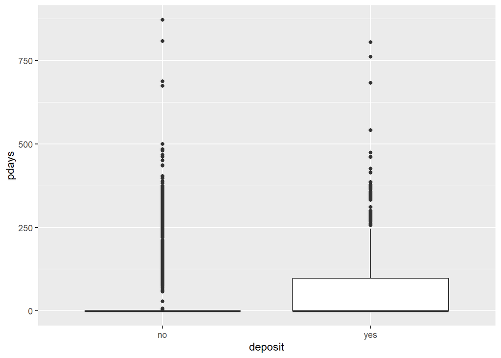

```r
ggplot(bank, aes(x = deposit, y = pdays)) +
  geom_boxplot()
```

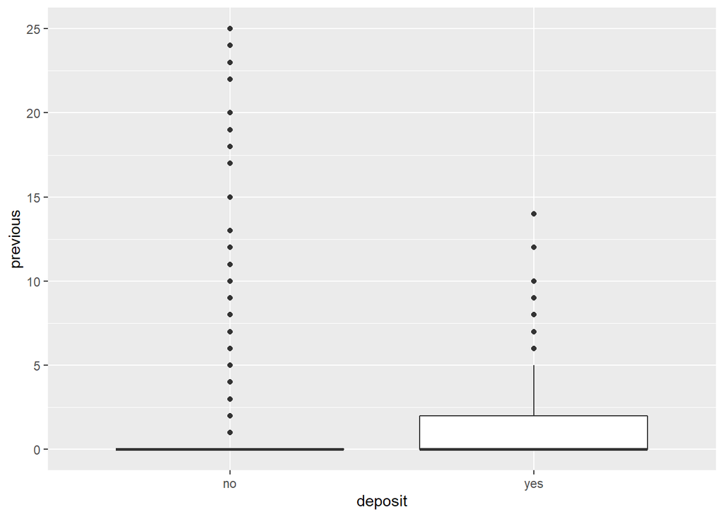

```r
ggplot(bank, aes(x = deposit, y = previous)) +
  geom_boxplot()
```

Above boxplots show graphical confirmation that only in a variable duration, there is a difference between means among two deposit groups.

### Discovering relationship between categorical variables and a target variable

#### Normalized histograms

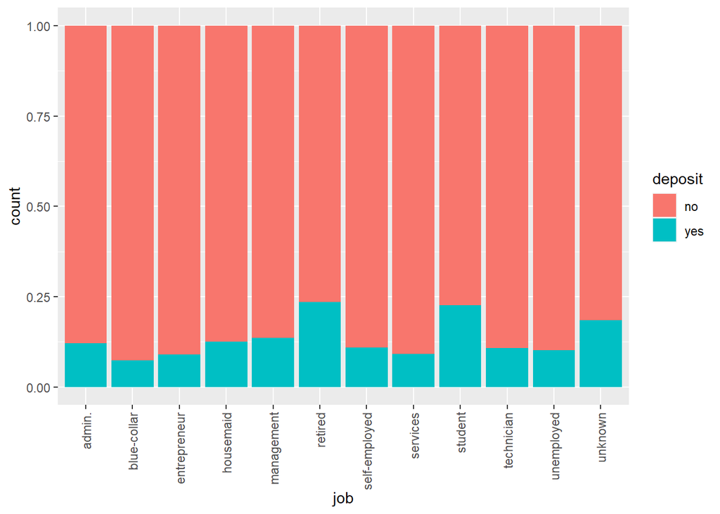

```r
ggplot(bank, aes(x = job, fill = deposit)) +
  geom_histogram(stat = "count", position = "fill") +
  theme(axis.text.x = element_text(
    angle = 90,
    vjust = 0.5,
    hjust = 1
  ))
```

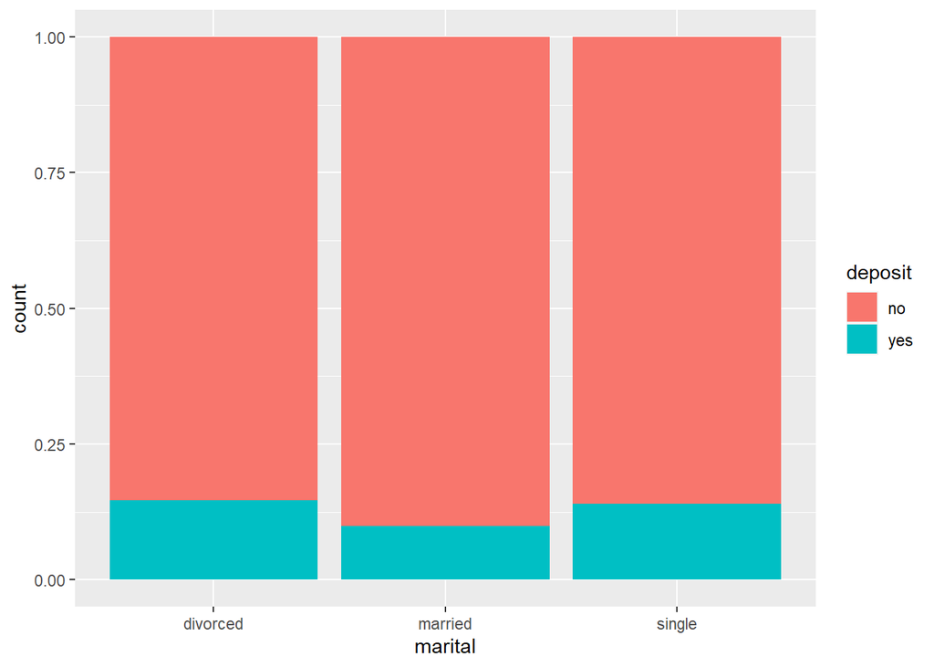

```r
ggplot(bank, aes(x = marital, fill = deposit)) +
  geom_histogram(stat = "count", position = "fill")
```

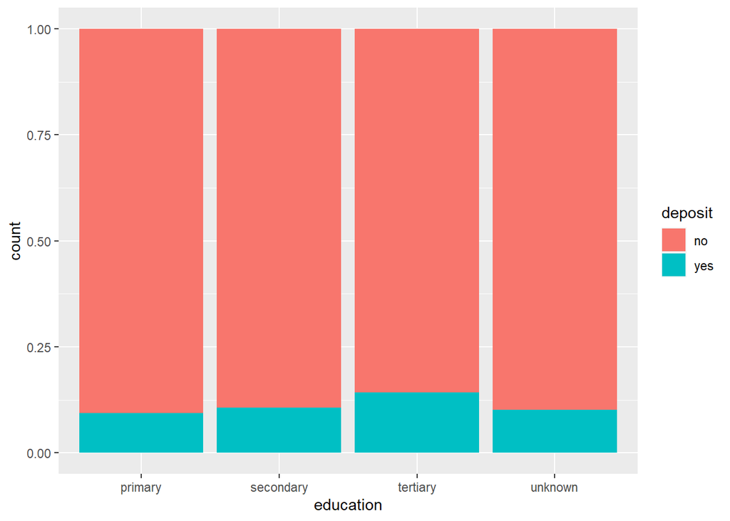

```r
ggplot(bank, aes(x = education, fill = deposit)) +
  geom_histogram(stat = "count", position = "fill")
```

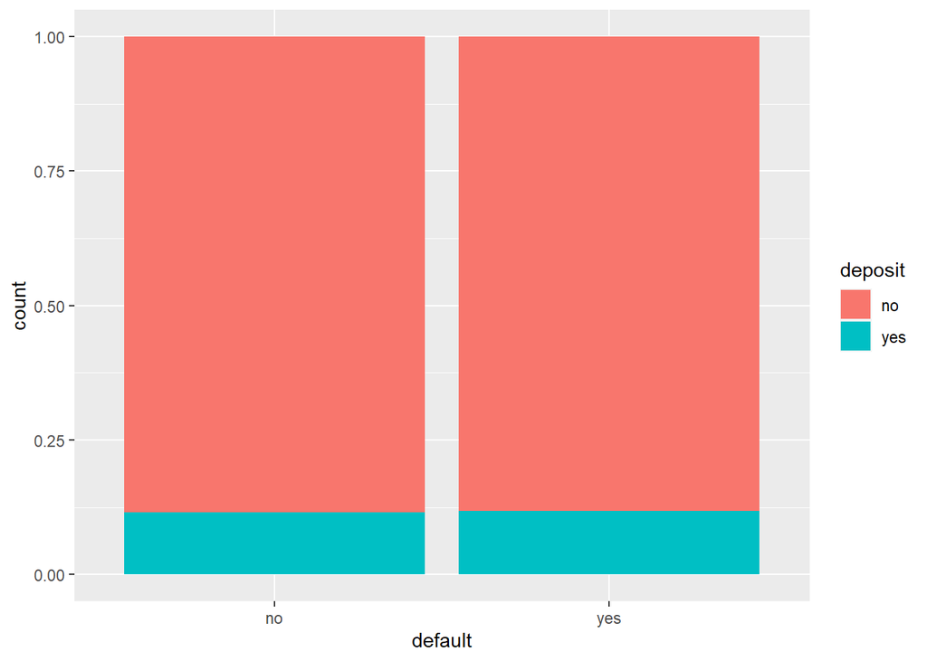

```r
ggplot(bank, aes(x = default, fill = deposit)) +
  geom_histogram(stat = "count", position = "fill")
```

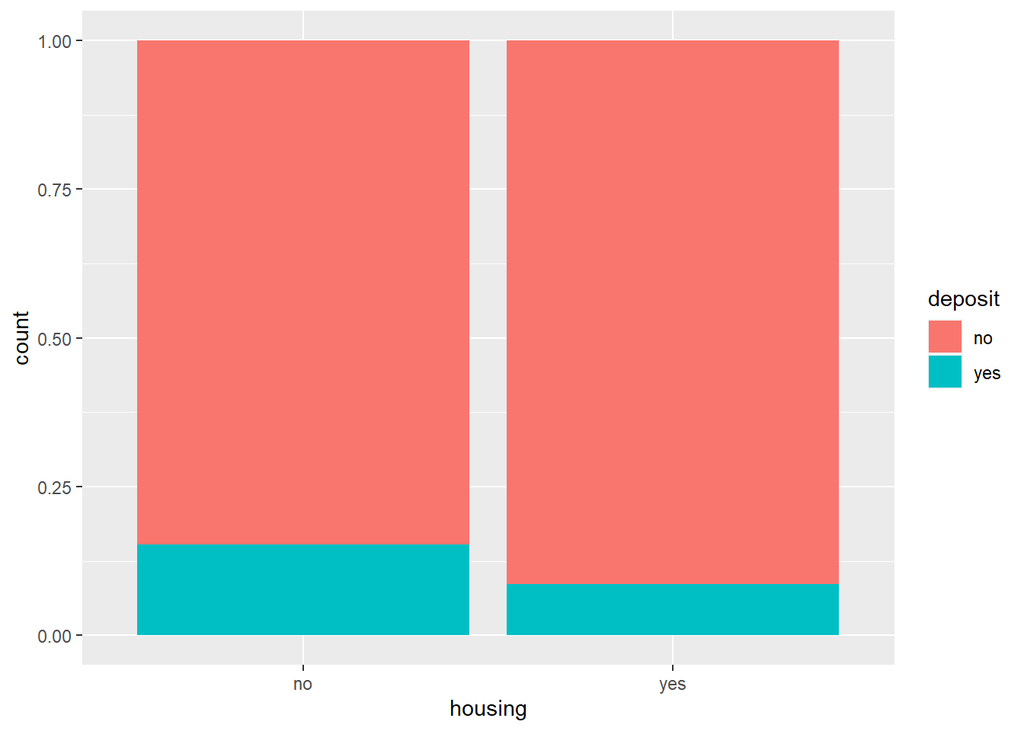

```r
ggplot(bank, aes(x = housing, fill = deposit)) +
  geom_histogram(stat = "count", position = "fill")
```

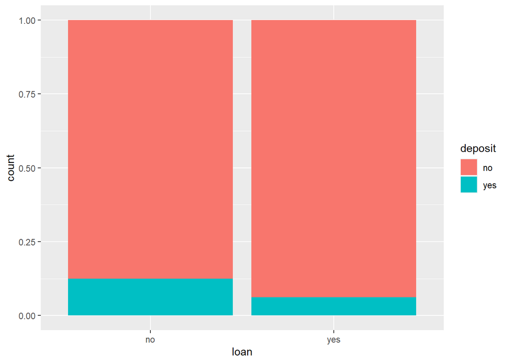

```r
ggplot(bank, aes(x = loan, fill = deposit)) +
  geom_histogram(stat = "count", position = "fill")
```

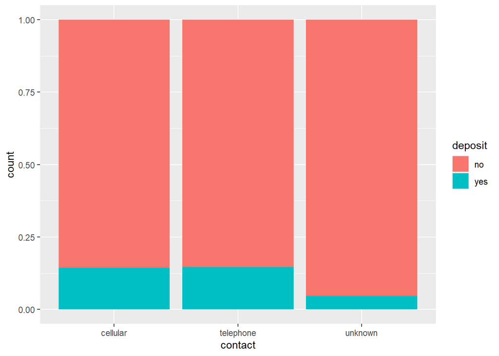

```r
ggplot(bank, aes(x = contact, fill = deposit)) +
  geom_histogram(stat = "count", position = "fill")
```

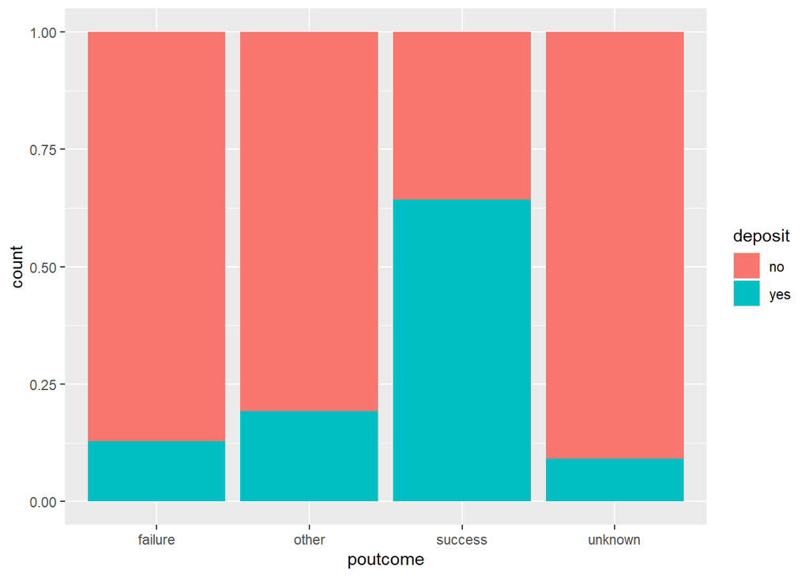

```r
ggplot(bank, aes(x = poutcome, fill = deposit)) +
  geom_histogram(stat = "count", position = "fill")
```

From histograms above, varaibles job, marital, education, housing, loan, poutcome shows clear differences on the ratio of deposit.

### Feature Selection

From information above, we choose job, marital, education, housing, loan, poutcome, and duration variables to predict a target variable deposit.

### Train Test Split

```r
set.seed(10)

data_sets = partition(data = bank, prob = c(0.7, 0.3))
data_sets_fs = data_sets
data_sets_fs$part1 = data_sets_fs$part1 %>% select(job,
                                                   marital,
                                                   education,
                                                   housing,
                                                   loan,
                                                   duration,
                                                   poutcome,
                                                   deposit)

data_sets_fs$part2 = data_sets_fs$part2 %>% select(job,
                                                   marital,
                                                   education,
                                                   housing,
                                                   loan,
                                                   duration,
                                                   poutcome,
                                                   deposit)

data_sets_fs$part1$duration = scale(data_sets_fs$part1$duration)
data_sets_fs$part2$duration = scale(data_sets_fs$part2$duration)

train_set = data_sets$part1
test_set  = data_sets$part2
train_set_fs = data_sets_fs$part1
test_set_fs = data_sets_fs$part2

train_label = train_set$deposit
test_label  = test_set$deposit
train_label_fs = train_set_fs$deposit
test_label_fs = test_set_fs$deposit
```

For the feature-selected-model, we standardized a numerical variable for a better performance.

### Split validation

```r
t.test( x = train_set $ duration, y = test_set $ duration )
```

```
##
##  Welch Two Sample t-test
##
## data:  train_set$duration and test_set$duration
## t = -0.48217, df = 2549.3, p-value = 0.6297
## alternative hypothesis: true difference in means is not equal to 0
## 95 percent confidence interval:
##  -20.92109  12.66297
## sample estimates:
## mean of x mean of y
##  262.6799  266.8090
```

P-value (0.62) is greater than 0.05 therefore, we do not reject that there is no mean difference between train and test data. So we assume our split is valid.

### Label distribution

```r
table(train_label)
```

```
## train_label
##   no  yes
## 2767  351
```

```r
table(test_label)
```

```
## test_label
##   no  yes
## 1233  170
```

```r
table(train_label_fs)
```

```
## train_label_fs
##   no  yes
## 2767  351
```

```r
table(test_label_fs)
```

```
## test_label_fs
##   no  yes
## 1233  170
```

### Applying KNN algorithm

We will apply KNN algorithms both to baseline model and our new feature-selected-model to compare how our feature selection has improved performance.

#### Baseline model (with all features)

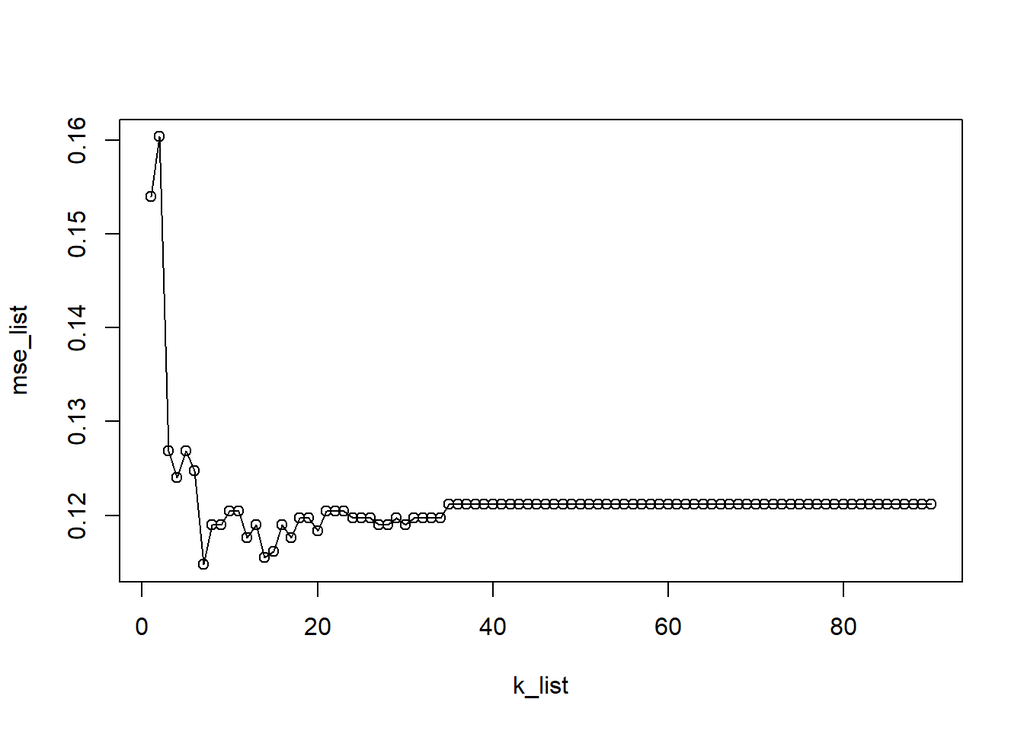

```r
k_list   = 1:90
mse_list = vector( length = length( k_list )  )

for( k in k_list ){
    knn_k = kNN( deposit ~ ., train = train_set, test = test_set, transform = "minmax", k = k )
    mse_list[ k ] = mse( test_label, knn_k )
}

plot( x = k_list, y = mse_list, type = "o" )
```

#### Feature-selected model

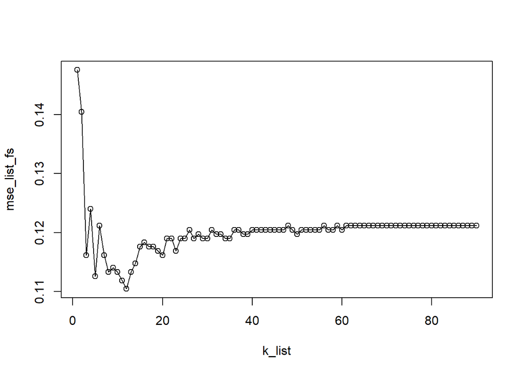

```r
mse_list_fs = vector(length = length(k_list))

for (k in k_list) {
  knn_k_fs = kNN(
    deposit ~ .,
    train = train_set_fs,
    test = test_set_fs,
    transform = "minmax",
    k = k
  )
  mse_list_fs[k] = mse(test_label_fs, knn_k_fs)
}

plot(x = k_list, y = mse_list_fs, type = "o")
```

### MSE at optimal K

```r
cat("MSE of baseline model : ", min(mse_list), "|| Optimal K: ", which.min(mse_list), "\n")
```

```
## MSE of baseline model :  0.1147541 || Optimal K:  7
```

```r
cat("MSE of feature-selected-model : ", min(mse_list_fs), "|| Optimal K: ", which.min(mse_list_fs))
```

```
## MSE of feature-selected-model :  0.1104775 || Optimal K:  12
```

The result show that our new model has improved in decreased in MSE by 0.0042766 compared to the original model.